# Matching BHRe episodes to CNR laboratory records

A step-by-step linkage report

10 July 2026

# 1 What this report does

We have two separate datasets that describe the same real-world events from two angles, but they share **no common ID number**:

- **BHRe episodes** — each row is a hospital *episode* reported to the national surveillance system (e-SIN). It tells us the hospital, the dates, the bacteria and its resistance mechanism, and whether the strain was sent to a national reference laboratory.
- **CNR records** — each row is a single *bacterial strain* that a hospital sent to the reference laboratory (CNR), where it was sequenced in detail.

Our goal is to figure out, for each BHRe episode, **which CNR strain(s) it corresponds to**. Because there is no shared ID, we match on the information the two datasets *do* have in common — when the strain was sent, what resistance mechanism it has, and which hospital it came from. Since no single clue is perfect, every match we keep is labelled with a **confidence level** (High or Medium; weak “Low” matches are thrown away).

# 2 Load the data

Three files are read in. `nodes` is a reference table that lets us look up a hospital’s **name and town** from its FINESS code (the BHRe episode file itself does not contain the hospital name).

```r
nodes <- readRDS(here("Datasets","Cleaned Model Input Data","node_attributes_enriched.RDS")) %>%
  mutate(finess_geo = as.numeric(finess_geo)) %>%
  filter(!is.na(finess_geo))

cnr  <- read_excel(here("Datasets","Output Data",
                        "CNR_2023_2024_DEIDENTIFIED_shareable_EN_clean.xlsx"))

bhre <- read.csv(here("Datasets","Sante Publique","Cleaned","bhre_2024_hosp.csv"))
bhre <- bhre[, 1:84]



# keep only the original BHRe episode columns
```

# 3 Step 1 — Add the hospital name and town to each episode

The BHRe file has a FINESS code but no hospital name or town. We use the `nodes` reference table to attach both, matching on the FINESS code.

```r
place_lu <- nodes %>%
  transmute(fin = fin9(finess_geo), facility_name_capact, city) %>%
  filter(!is.na(fin)) %>%
  distinct(fin, .keep_all = TRUE)

bhre <- bhre %>%
  mutate(fin = fin9(facility_finess_code)) %>%
  left_join(place_lu, by = "fin")
```

# 4 Step 2 — Keep only episodes sent to the EPC reference lab

The `cnr_referral` field records *which* reference lab a strain was sent to. Only strains sent to the **EPC carbapenemase CNR (Kremlin-Bicêtre)** appear in our CNR dataset, so we keep only those episodes. Strains sent elsewhere (for example the enterococci lab in Rennes) cannot possibly be in this CNR file, so they are set aside.

```r
n_epc <- sum(bhre$cnr_referral == EPC_LAB, na.rm = TRUE)
epc <- bhre %>% filter(cnr_referral == EPC_LAB)
```

**1016** episodes were sent to the EPC CNR.

# 5 Step 3 — Work out the clues we will match on (BHRe side)

For every episode we prepare the pieces of information used for matching:

- **When it was sent** — the date the strain was referred to the CNR (`cnr_referral_date`). This is the right date to use because the CNR’s `sample_month`/`sample_year` are actually the **date the strain was received** at the lab, which lines up with the referral date, not the original sampling date.
- **The resistance mechanism** — both the broad family (e.g. NDM, VIM, OXA-48 group) and the exact variant (e.g. NDM-5).
- **The hospital’s department** — the first two digits of its FINESS code.
- **The hospital name and town** — broken into meaningful words for name-matching.

```r
epc <- epc %>%
  mutate(
    ref_date = if (isTRUE(params$date_fallback_form_issue))
                 coalesce(as.Date(cnr_referral_date), as.Date(form_issue_date))
               else as.Date(cnr_referral_date),
    ref_ym    = ym_int(year(ref_date), month(ref_date)),
    bhre_dept = str_sub(fin, 1, 2),
    bhre_mech = pmap_chr(select(., all_of(mech_cols)),
                         ~ paste(sort(unique(toupper(na.omit(c(...))))), collapse = " | ")),
    bhre_var  = pmap(select(., all_of(mech_cols)), ~ toupper(na.omit(unique(c(...))))),
    bhre_fam  = map(bhre_var, ~ unique(na.omit(map_chr(.x, carb_family_one)))),
    name_tok  = tokenize_place(facility_name_capact),
    city_tok  = tokenize_place(city)
  )

n_have_refdate <- sum(!is.na(as.Date(epc$cnr_referral_date)))
bhre_prep <- epc %>% filter(!is.na(ref_ym), lengths(bhre_fam) > 0)
n_keyed <- n_distinct(bhre_prep$ehesp_id)
```

**Important coverage point.** A referral date is only recorded for **591** of the 1016 referred episodes (58%). Episodes with no referral date cannot be placed in time and are dropped. After also requiring a recognised carbapenemase family, **581** episodes are ready to match. (If you would rather fill the gap, set `params$date_fallback_form_issue = TRUE` to use the form-submission date when the referral date is missing.)

# 6 Step 4 — Prepare the same clues on the CNR side

We do the equivalent on the CNR records. One record can list two mechanisms (“NDM-5 + OXA-48”); we split these so the record counts under both families.

```r
cnr_prep <- cnr %>%
  filter(!is_environment %in% TRUE) %>%                 # ignore environmental swabs
  mutate(
    cnr_ym   = ym_int(2000L + as.integer(sample_year), as.integer(sample_month)),
    cnr_dept = coalesce(str_sub(str_extract(as.character(department_code), "[0-9]+"), 1, 2),
                        str_sub(str_extract(as.character(zip_code_facility), "[0-9]+"), 1, 2)),
    cnr_name_tok = tokenize_place(facility_name),
    cnr_var  = map(sequencing, variants_of),
    family   = map(sequencing, families_of)
  ) %>%
  filter(lengths(family) > 0, !is.na(cnr_ym)) %>%
  unnest(family)
```

# 7 Step 5 — Make the match and score it

**The rule for proposing a match:** an episode and a CNR record are only paired if they have the **same mechanism family** *and* the referral month is **within ±1 month** of the CNR receipt month. This is the non-negotiable minimum.

**Scoring the strength of a match:** on top of that, we add points for extra agreement. The more independent clues line up, the higher the score.

| Extra agreement | Points |
| --- | --- |
| exact mechanism variant matches | 2 |
| hospital **name** matches (tier 1) | 3 |
| hospital name matches the **town** (tier 2) | 2 |
| same department | 1 |
| exact same month | 1 |

**Confidence:** `High` = 4 points or more; `Medium` = 2–3; `Low` = 1 or less. Low matches are removed.

```r
bhre_keyed <- bhre_prep %>%
  mutate(ym = map(ref_ym, ~ seq(.x - tol_months, .x + tol_months))) %>%
  select(ehesp_id, ref_date, ref_ym, bhre_dept, city, facility_name_capact,
         bhre_mech, bhre_var, name_tok, city_tok, family = bhre_fam, ym) %>%
  unnest(family) %>% unnest(ym)

candidates <- bhre_keyed %>%
  inner_join(cnr_prep, by = c("family", "ym" = "cnr_ym"),
             relationship = "many-to-many") %>%
  mutate(
    month_exact   = ym == ref_ym,
    variant_exact = map2_lgl(bhre_var, cnr_var, has_overlap),
    dept_match    = !is.na(bhre_dept) & !is.na(cnr_dept) & bhre_dept == cnr_dept,
    name_t1 = map2_lgl(cnr_name_tok, name_tok, has_overlap),   # CNR name vs hospital name
    name_t2 = map2_lgl(cnr_name_tok, city_tok, has_overlap),   # CNR name vs town
    name_tier  = case_when(name_t1 ~ "tier1_name", name_t2 ~ "tier2_city", TRUE ~ NA_character_),
    name_score = case_when(name_t1 ~ 3L, name_t2 ~ 2L, TRUE ~ 0L),
    score = 2L*variant_exact + name_score + dept_match + month_exact,
    confidence = case_when(score >= 4 ~ "High", score >= 2 ~ "Medium", TRUE ~ "Low") %>%
                 factor(levels = c("High","Medium","Low")),
    match_keys = pmap_chr(list(variant_exact, name_tier, dept_match, month_exact),
      function(v,nt,d,m) paste(c("family+month", if (v) "variant",
        if (!is.na(nt)) nt, if (d) "dept", if (m) "exact-month")[c(TRUE,v,!is.na(nt),d,m)],
        collapse="+"))
  )
```

# 8 Step 6 — Keep the best match(es) per episode

For each episode we keep its highest-scoring CNR record(s) and drop anything that only reached Low confidence. **An episode is allowed to match several CNR records** — this is expected and correct, because a hospital often sends several strains to the CNR in the same month and there is no patient-level key to single one out.

```r
bhre_cnr_matches <- candidates %>%
  group_by(ehesp_id) %>% mutate(is_best = score == max(score)) %>%
  filter(is_best, confidence != "Low") %>% ungroup() %>%
  transmute(ehesp_id, patient_id, specimen_id, confidence, score, name_tier, match_keys,
            ref_date, family, bhre_mech, cnr_sequencing = sequencing,
            bhre_facility_name = facility_name_capact, cnr_facility_name = facility_name,
            bhre_city = city, bhre_dept, cnr_dept,
            cnr_sample_month = sample_month, cnr_sample_year = sample_year,
            cnr_species = species)

episode_methods <- bhre_cnr_matches %>%
  group_by(ehesp_id) %>%
  summarise(confidence = first(confidence),
            name_method = case_when(
              any(name_tier == "tier1_name", na.rm = TRUE) ~ "tier1_name",
              any(name_tier == "tier2_city", na.rm = TRUE) ~ "tier2_city",
              TRUE ~ "none_no_name"),
            used_variant = any(str_detect(match_keys, "variant")),
            used_dept    = any(str_detect(match_keys, "dept")),
            used_month   = any(str_detect(match_keys, "exact-month")),
            n_cnr_specimens = n_distinct(specimen_id), .groups = "drop")
```

# 9 Results

## 9.1 How many episodes matched

```r
n_matched <- n_distinct(bhre_cnr_matches$ehesp_id)
tibble(step = c("Episodes sent to the EPC CNR",
                "Ready to match (had a referral date and a known mechanism)",
                "Matched (High or Medium; Low removed)",
                "   - High confidence",
                "   - Medium confidence"),
       episodes = c(n_epc, n_keyed, n_matched,
                    sum(episode_methods$confidence == "High"),
                    sum(episode_methods$confidence == "Medium"))) %>%
  kable(caption = "Episodes through the matching pipeline")
```

Episodes through the matching pipeline

| step | episodes |
| --- | --- |
| Episodes sent to the EPC CNR | 1016 |
| Ready to match (had a referral date and a known mechanism) | 581 |
| Matched (High or Medium; Low removed) | 550 |
| - High confidence | 459 |
| - Medium confidence | 91 |

## 9.2 Which method carried each match

```r
episode_methods %>%
  mutate(name_method = recode(name_method,
    tier1_name  = "Matched on hospital name",
    tier2_city  = "Matched on town",
    none_no_name= "No name clue (family + dept + month)")) %>%
  count(name_method, confidence) %>%
  pivot_wider(names_from = confidence, values_from = n, values_fill = 0) %>%
  kable(caption = "How each episode's best match was made")
```

How each episode’s best match was made

| name_method | High | Medium |
| --- | --- | --- |
| Matched on hospital name | 331 | 5 |
| Matched on town | 41 | 5 |
| No name clue (family + dept + month) | 87 | 81 |

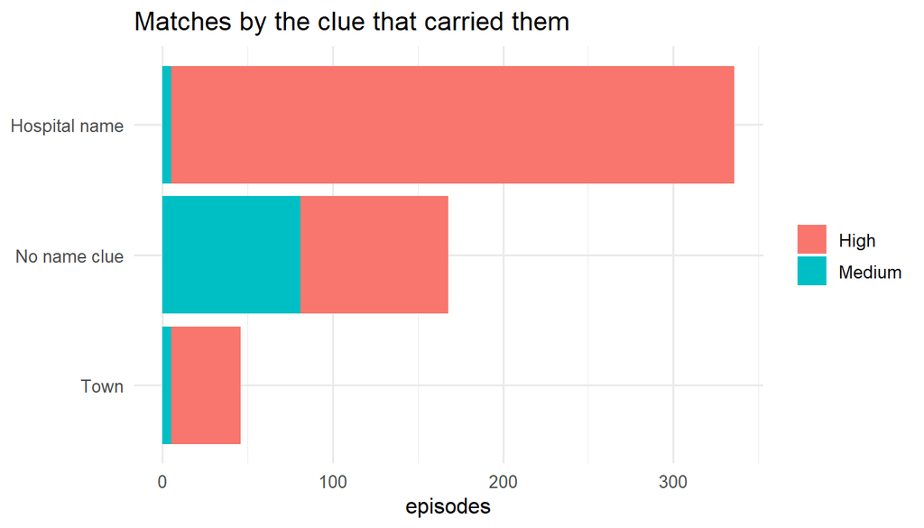

## 9.3 Which clues were used

```r
tibble(clue = c("Exact mechanism variant", "Same department", "Exact same month"),
       episodes_using_it = c(sum(episode_methods$used_variant),
                             sum(episode_methods$used_dept),
                             sum(episode_methods$used_month))) %>%
  kable(caption = paste0("Of the ", n_matched,
        " matched episodes, how many used each clue (all also matched family + month)"))
```

Of the 550 matched episodes, how many used each clue (all also matched family + month)

| clue | episodes_using_it |
| --- | --- |
| Exact mechanism variant | 356 |
| Same department | 348 |
| Exact same month | 390 |

## 9.4 One episode can match several strains

```r
tibble(measure = c("Episodes matching exactly one CNR strain",
                   "Episodes matching more than one CNR strain",
                   "Different CNR strains linked in total",
                   "Total episode-strain pairs kept",
                   "Typical (median) strains per episode"),
       value = c(sum(episode_methods$n_cnr_specimens == 1),
                 sum(episode_methods$n_cnr_specimens > 1),
                 n_distinct(bhre_cnr_matches$specimen_id),
                 nrow(bhre_cnr_matches),
                 median(episode_methods$n_cnr_specimens))) %>%
  kable(caption = "Match multiplicity (this is expected, not an error)")
```

Match multiplicity (this is expected, not an error)

| measure | value |
| --- | --- |
| Episodes matching exactly one CNR strain | 201 |
| Episodes matching more than one CNR strain | 349 |
| Different CNR strains linked in total | 4254 |
| Total episode-strain pairs kept | 12684 |
| Typical (median) strains per episode | 2 |

## 9.5 A look at some High-confidence matches

```r
bhre_cnr_matches %>% filter(confidence == "High") %>%
  select(ref_date, family, bhre_mech, cnr_sequencing,
         bhre_facility_name, cnr_facility_name, bhre_city, match_keys) %>%
  head(10)
```

| ref_date | family | bhre_mech | cnr_sequencing | bhre_facility_name | cnr_facility_name | bhre_city | match_keys |
| --- | --- | --- | --- | --- | --- | --- | --- |
| 2024-10-14 | OXA48 | OXA-48 | NDM-5 + OXA-48 | CH AGGLOMERATION MONTARGOISE | MEDIBIOLAB SARAN | Amilly | family+month+variant+exact-month+NA |
| 2024-10-14 | OXA48 | OXA-48 | OXA-48 | CH AGGLOMERATION MONTARGOISE | ORLEANS | Amilly | family+month+variant+exact-month+NA |
| 2024-10-14 | OXA48 | OXA-48 | OXA-48 | CH AGGLOMERATION MONTARGOISE | MEDIBIOLAB SARAN | Amilly | family+month+variant+exact-month+NA |
| 2024-10-14 | OXA48 | OXA-48 | OXA-181 | CH AGGLOMERATION MONTARGOISE | AMILLY - MONTARGIS | Amilly | family+month+dept+exact-month+NA |
| 2024-10-14 | OXA48 | OXA-48 | OXA-181 | CH AGGLOMERATION MONTARGOISE | AMILLY - MONTARGIS | Amilly | family+month+dept+exact-month+NA |
| 2024-10-14 | OXA48 | OXA-48 | NDM-1 + OXA-48 | CH AGGLOMERATION MONTARGOISE | ORLEANS | Amilly | family+month+variant+exact-month+NA |
| 2024-10-14 | OXA48 | OXA-48 | OXA-181 | CH AGGLOMERATION MONTARGOISE | AMILLY - MONTARGIS | Amilly | family+month+dept+exact-month+NA |
| 2024-10-14 | OXA48 | OXA-48 | OXA-181 | CH AGGLOMERATION MONTARGOISE | AMILLY - MONTARGIS | Amilly | family+month+dept+exact-month+NA |
| 2024-10-14 | OXA48 | OXA-48 | OXA-48 | CH AGGLOMERATION MONTARGOISE | MEDIBIOLAB SARAN | Amilly | family+month+variant+exact-month+NA |
| 2024-10-14 | OXA48 | OXA-48 | OXA-181 | CH AGGLOMERATION MONTARGOISE | AMILLY - MONTARGIS | Amilly | family+month+dept+exact-month+NA |

# 10 Save the results

```r
write_csv(bhre_cnr_matches, here("Datasets","Output Data","bhre_cnr_matches.csv"))
write_csv(episode_methods,  here("Datasets","Output Data","bhre_cnr_episode_methods.csv"))
```

# 11 Things to keep in mind